# Parsing mPFC: Community analysis

CTS & JTM

## Partition Comparison: Full Datasets

This just gives an idea of the level of agreement within and between subjects. The first plot shows how well (in approx %) do modularity and spectral partitioning agree in parsing PCC and mPFC.

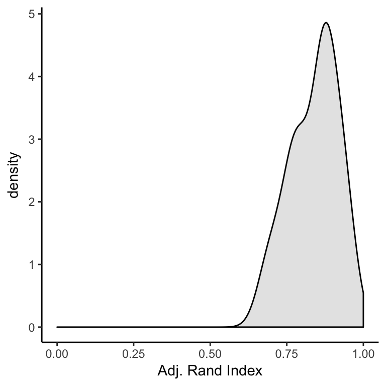

The following set of similarity matrices show every pairwise comparison among all subjects, based on RI. The matrix on the left shows similarities for the whole brain, while the one on the right shows similarities for PCC (lower) and PFC (upper) separately.

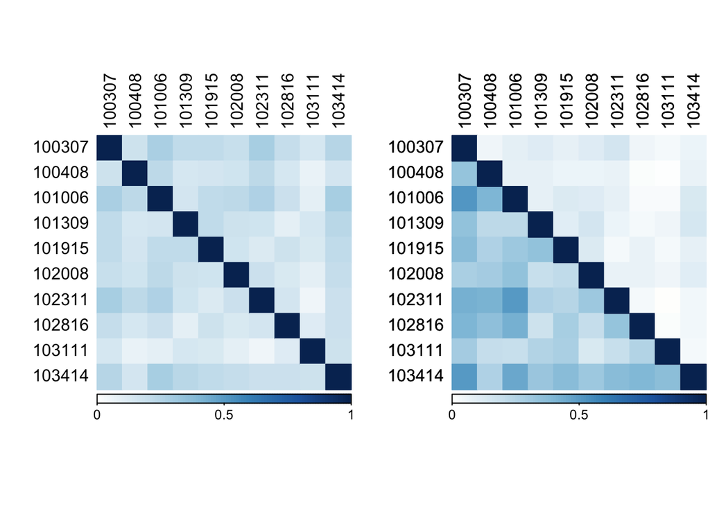

## Partition Comparison: Halves

HCP resting state data is separated into 4 runs (2 per day of scanning). This section shows how much agreement there is between partitions taken on each day. The similarity matrix on the left shows the pairwise level of agreement for the overall data among all subjects, while the right one divides this data into PCC and mPFC.

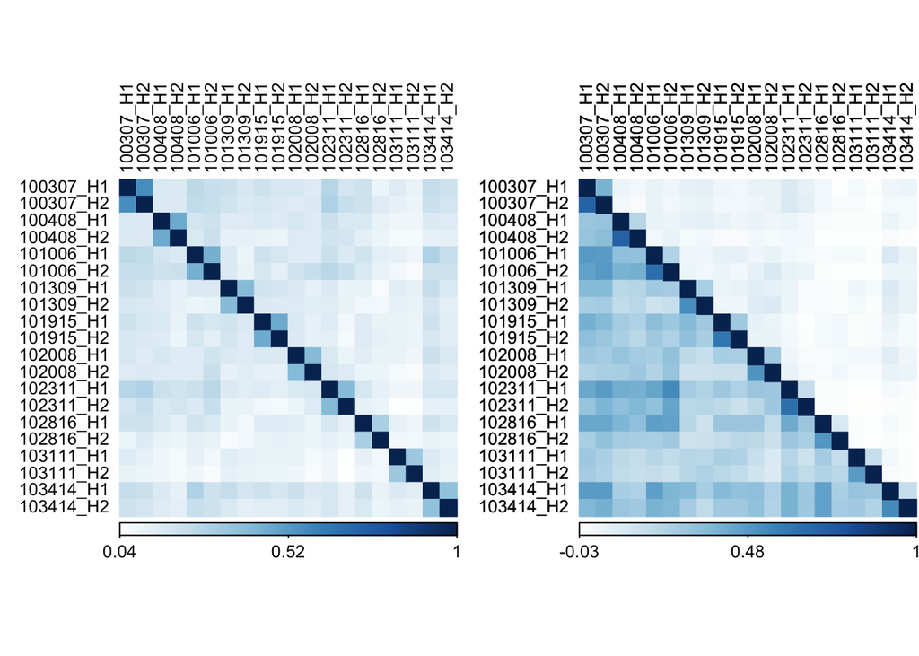

## Partition Comparison: Session

Next, each session is evaluated independently. The similarity matrix shows how each session data corresponded within and between subjects for PCC and mPFC separately.

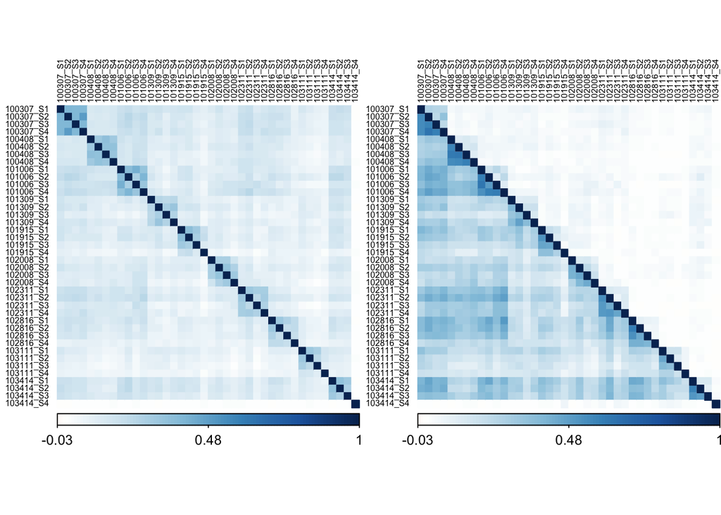

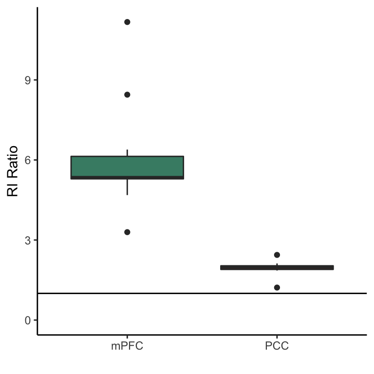

Another way is based on Kragel et al. (2018), who quantified the dissimilarity of brain patterns for study-, subdomain-, and domain-specific (or how generalizeable the patterns are at each hierarchical level). In this case, for 10 subjects 30 matrices are created (20 for within-day comparisons, 10 for within subject comparisons). Each atrix is binarized to compare a subject’s level of similarity within their sessions vs across every other subject’s sessions. The 30 matrices are vectorized and used as predictors in a GLM with a quasibinomial distribution, where the dependent data is the full similarity matrix. The table shows the results.

Fitting generalized (quasibinomial/logit) linear model: tempY ~ .

|  | Estimate | Std. Error | t value | Pr(> |
| --- | --- | --- | --- | --- |
| **(Intercept)** | 5.6 | 0.7 | 8 | 4.7e-15 |
| **`100307_H1`** | 0.33 | 0.074 | 4.5 | 8e-06 |
| **`100307_H2`** | 0.3 | 0.074 | 4 | 6.3e-05 |
| **`100408_H1`** | 0.19 | 0.078 | 2.5 | 0.013 |
| **`100408_H2`** | 0.09 | 0.078 | 1.2 | 0.25 |
| **`101006_H1`** | 0.17 | 0.076 | 2.3 | 0.022 |
| **`101006_H2`** | 0.2 | 0.076 | 2.7 | 0.0079 |
| **`101309_H1`** | 0.05 | 0.082 | 0.61 | 0.54 |
| **`101309_H2`** | -0.1 | 0.082 | -1.3 | 0.21 |
| **`101915_H1`** | 0.13 | 0.084 | 1.5 | 0.13 |
| **`101915_H2`** | -0.3 | 0.084 | -3.6 | 0.00039 |
| **`102008_H1`** | 0.025 | 0.083 | 0.31 | 0.76 |
| **`102008_H2`** | -0.11 | 0.083 | -1.4 | 0.17 |
| **`102311_H1`** | 0.16 | 0.081 | 2 | 0.051 |
| **`102311_H2`** | -0.19 | 0.081 | -2.3 | 0.023 |
| **`102816_H1`** | 0.024 | 0.086 | 0.28 | 0.78 |
| **`102816_H2`** | -0.31 | 0.086 | -3.6 | 0.00029 |
| **`103111_H1`** | -0.0097 | 0.091 | -0.11 | 0.92 |
| **`103111_H2`** | -0.42 | 0.091 | -4.6 | 5.5e-06 |
| **`103414_H1`** | 0.014 | 0.098 | 0.14 | 0.89 |
| **`103414_H2`** | -0.84 | 0.098 | -8.6 | 6.5e-17 |
| **`100307`** | -0.55 | 0.068 | -8 | 5.5e-15 |
| **`100408`** | -0.68 | 0.072 | -9.4 | 5.4e-20 |
| **`101006`** | -0.47 | 0.07 | -6.7 | 3.7e-11 |
| **`101309`** | -0.64 | 0.077 | -8.3 | 3.7e-16 |
| **`101915`** | -0.69 | 0.079 | -8.7 | 2.2e-17 |
| **`102008`** | -0.68 | 0.078 | -8.7 | 1.7e-17 |
| **`102311`** | -0.53 | 0.076 | -7 | 6.7e-12 |
| **`102816`** | -0.54 | 0.081 | -6.7 | 3.3e-11 |
| **`103111`** | -0.92 | 0.086 | -11 | 5.6e-25 |
| **`103414`** | -0.31 | 0.094 | -3.3 | 0.00098 |

A significantly negative subject predictor says that the odds of the partitions being similar across subjects are much lower than those within each subject (across sessions). That is exactly what we see, with some important variance explained by day of testing (H* predictors, portraying day-specific comparisons; for some subjects only).

## Stability per subject

It is also worth considering how stable these measures are, so we performed a sliding window analysis (20 min windows shifting at ~1 min). The first two plots show how well each window’s clustering agreed with the partition derived from the whole data, as well as how variable this index was throughout the time series.

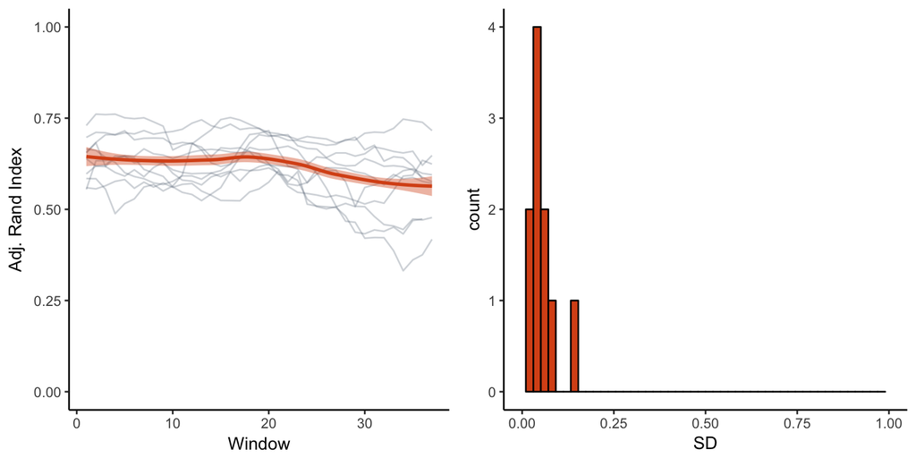

The next three show similar data, but for PCC and mPFC separately. The middle plot compares the mean adjusted Rand Index per subject for PCC and mPFC. While mPFC shows an overall significantly lower level of agreement with the overall partition, the variance throughout the time series is small (i.e. stable).

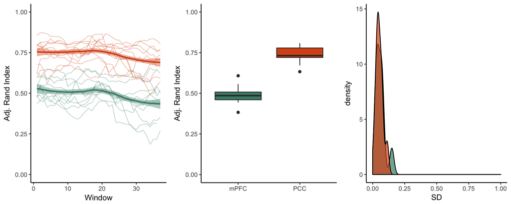

However, the last plot shows that the SNR is lower for mPFC than PCC, which could negatively affect our results.

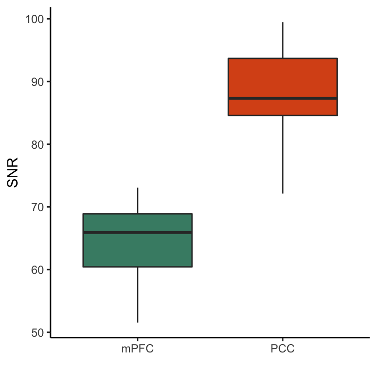

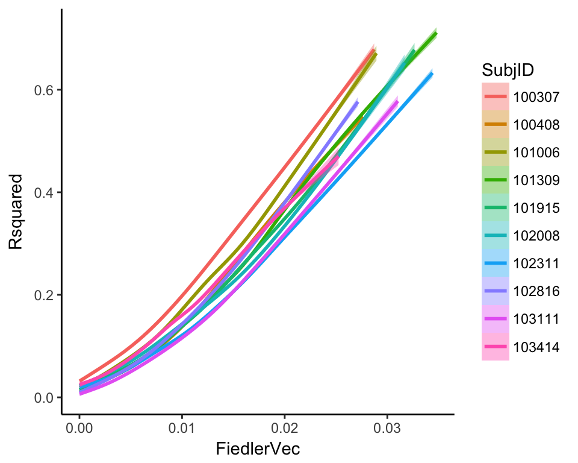

Next, I compared the R-squared for PCC and mPFC separately. The following plot shows that for each subject, R-squared values tend to be higher for PCC (this is also true for Fiedler vector values, but to a lesser expense). This difference is significant, with moderately high effect sizes.

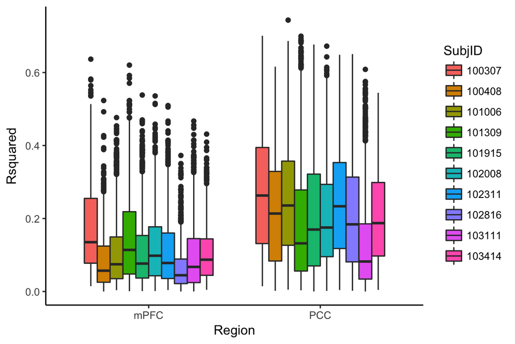

This begs the question of whether there is a “gradient of noise” along the z-axis on mPFC (vmPFC explaining less variance?). Not really, the R-squared values are mostly evenly distributed along the ventral-dorsal axis. However, the coefficient of variation derived from minimally preprocessed data does show a strong trend (namely, the more ventral, the lower the SNR).

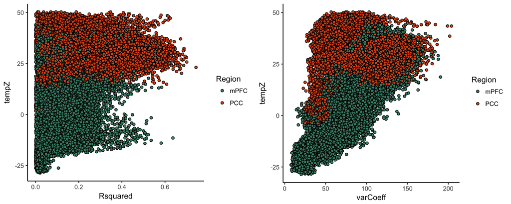

## Correlation vs community detection in mPFC

Finally, it is worth examining what we gain from using graph theoretic approaches over a simple seed-based functional connectivity analysis from PCC. The similarity matrix shows how Day 1 vs Day 2 comparisons for mPFC partitions generated with seed-based correlations (top-left quadrant) vs community detection (bottom-right) across all participants, as well as how much did these methods agree with each other (not much, but enough, which is good).

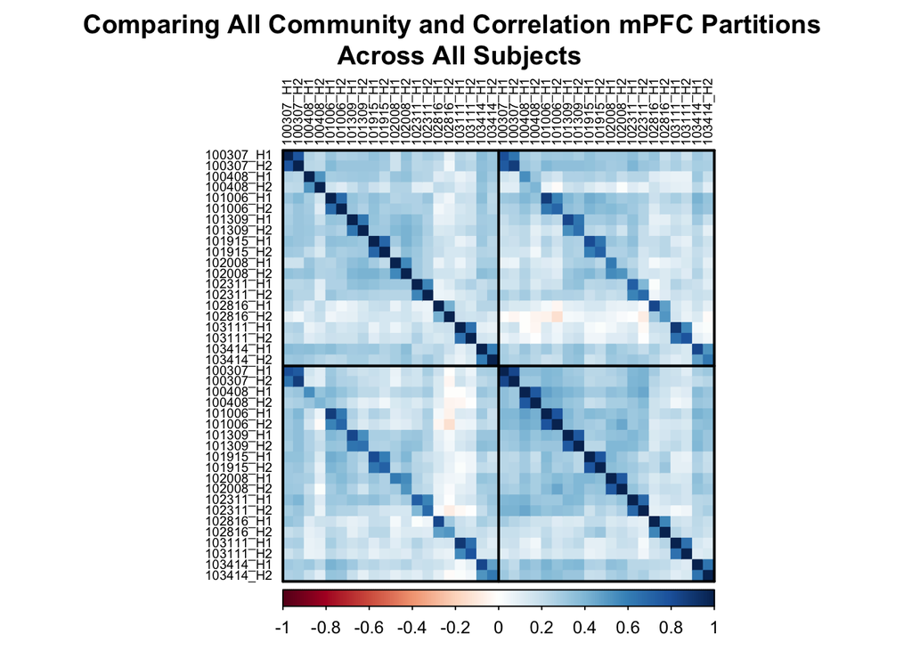

The final plot shows the spatial correlation between days for each method across participants. Community detection was significantly more stable across days than a simple correlation, even though mPFC has relatively low signal to noise ratio. Low intra-subject and high inter-subject variability of DMN partitions is in agreement with previous papers (Laumann 2015; Gordon et al., 2017; Braga & Buckner, 2017; Kong…Yeo, 2018). Graph-based community detection might thus be a better way to detect stable functional topologies, since high stability throughout days is a consistent feature of DMN topologies.

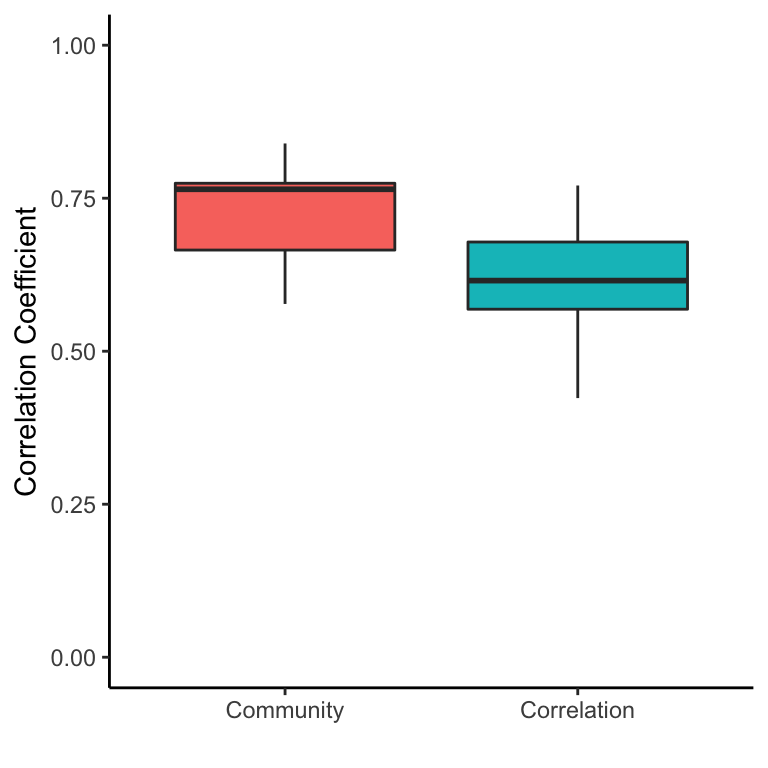